# Score-based GWAS in GAIT2

Andrey Ziyatdinov, Angel Martinez  
bit.ly/1KfPaLc

# Agenda

- Introduction
- Proposed analysis
- Results
  - 2 Demos
- Conclusions
  - Things we’ve learned
  - Other QTL mappings we’ve done
  - Things to do
- Additional figures

# Motivation

The boss told us …

1. We have millions of SNPs. We need to do GWAS discovering new loci!
   - Look. For sure, we will get ultra-fashioned new loci and publish the articles.
   - Why? We have hundreds of phenotypes! It is just like a lottery.
2. Diseases are the most important phenotypes!
   - GAIT2 has records of CVI (a *fashion* phenotype).

# Exploration: SOLAR is slow

- Server bioinf02: RAM 128G, 64 CPU 2.3G
- SOLAR 7.6.6 (stable on March, 2015)
- GAIT2: N = 934, M = 10M

| Model | Time (days) |
| --- | --- |
| F11~1 | 1.2 |
| F11~AGE+SEX | 1.6 |
| F11~1+H | 5.6 |
| F11~AGE+SEX+H | 8.2 |
| Thr~1 | 7.6 |
| Thr~AGE+SEX | 13.2 |
| Thr~1+H | 14.1 |
| Thr~AGE+SEX+H | 23.0 |

# Exploration: lme4 is not fast enough

`solaris` is an R package for QTL mapping based on `lme4`. Developed in the UGCD group.

| Model | SOLAR (days) | lme4 (days) |
| --- | --- | --- |
| F11~1 | 1.2 | 1.6 |
| F11~AGE+SEX | 1.6 | 1.6 |
| F11~1+H | 5.6 | 1.7 |
| F11~AGE+SEX+H | 8.2 | 1.7 |

Source: cputime.md

Note: all computation times are extrapolated from 24K to 10M.

# Proposed analysis

# Workflow 0: data preparation

1. Prepare phenotypes
   - 81 traits: inormal transformation + AGE/SEX covariates (04-assoc-mapping3-MatrixLmer)
   - 21 traits: outlier detection + exclusion criteria + custom transformation + AGE/AGE2/SEX covariates (05-assoc-mapping4-MatrixLmer)
2. Prepare genotypes
   - A mix of data formats: NCDF from [GWASTools](https://bioconductor.org/packages/release/bioc/html/GWASTools.html) + genocov by SOLAR, split into batches
   - The last version of filters: MAF >= `0.01`, info >= `0.3` *(Verma et al. 2014)*
   - `18,208,087` imputed and missing annotation, annotation.md:
     - `440,948` after IMPUTE2 (hg19)
     - `108,846` after 1K (hg19)
     - `46,054` after 1K + UCSC (hg19, snpDB 142)

# Workflow 1: MatrixEQTL + lme4/SOLAR

1. Estimate polygenic model and get the covariance matrix
2. Run MatrixEQTL in parallel (M = 10M)
3. Apply `pvOutputThreshold` = `1e-3` (`1e-4` in the first mappings 2-3)
4. Run lme4 in parallel (M = 100K-300K)

Source: 17-run-assoc-mapping4.R

# Workflow 2: GLOGS + SOLAR

GLOGS is a genome-wide logistic mixed model/score test *(Stanhope & Abney, 2012)*

1. Estimate GLOGS polygenic model (a random sample or cubature for `L(theta)`)
2. Run GLOGS association score-based model in parallel (M = 10M).
3. Apply p-value threshold `1e-3`.
4. Run SOLAR in parallel (M = 100K-200K)

Source: 01-run-polygenic.R & 02-run-assoc.R

# Results

# Summary

- Feasible computation time
  - None of the suggestive loci (p < 1e-5) is lost
- 2 / 81 phenotypes revealed new loci
  - mPGES1
  - SAHhplc/SAHsah (gene *PCMT1*)
- Is GWAS in GAIT2 trending?
  - CVI
  - APTT

# Computation times

[output not shown]

GWAS of GAIT2 by the proposed score-based methods: 100 phenotypes in 33 hours; 15 diseases in 4 days

# `inorm_mPGES1`

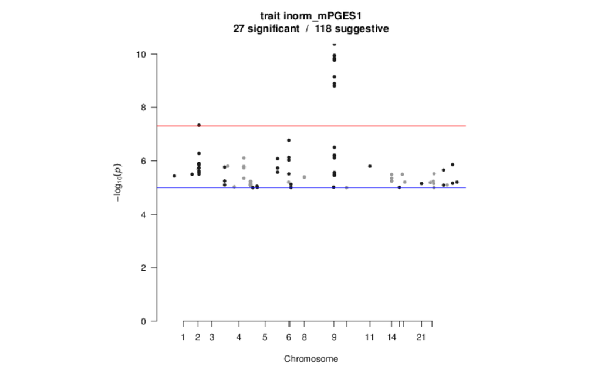

# `inorm_SAHhplc`, gene PCMT1

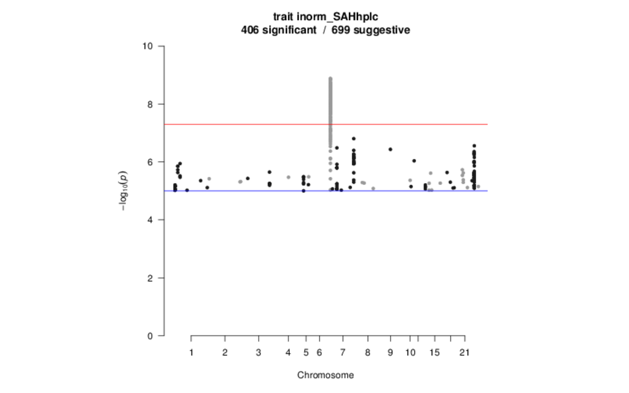

# `CVI` in GAIT2

N = 934 (60 cases), M = 9M

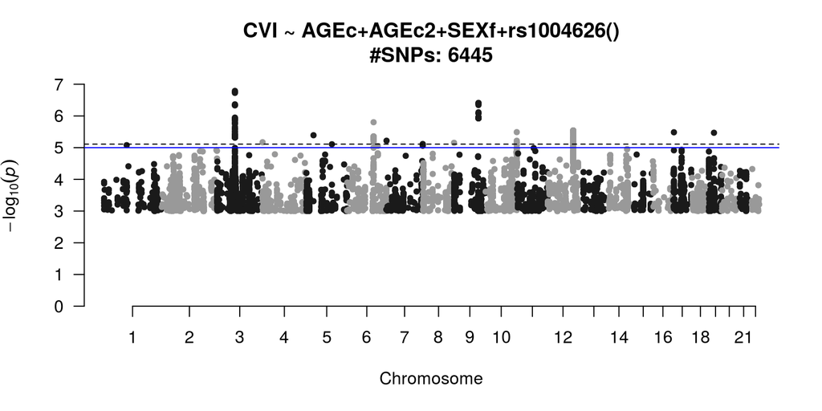

```r
library(gait)
A <- gait2.results.assoc("CVI", maf = 0.05, alpha = 1e-3)
plot(A)
```

# `CVI` in 23andMe

N = 92,666 (23,565 cases), M = 14M *(Bell et al., 2014)*

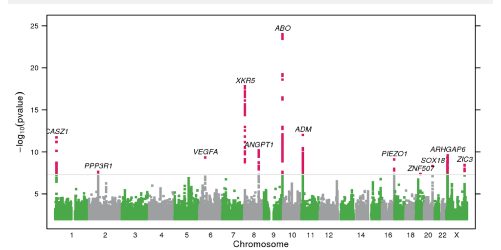

# `APTT` in GAIT2

N = 883, M = 9M  
3 loci: F12, KNG1, AB0

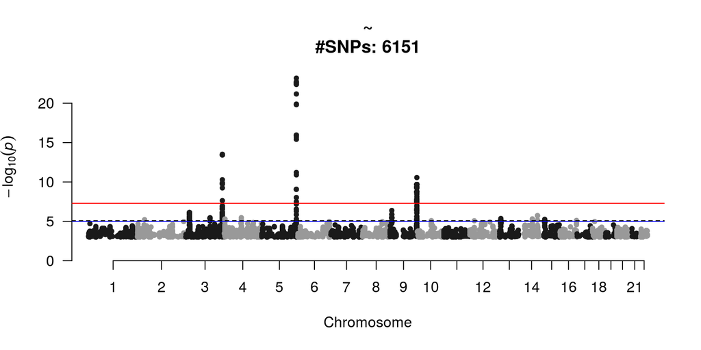

```r
library(gait)
A <- gait2.results.assoc("tr1_APTT", maf = 0.05, alpha = 1e-3)
plotManh(A)
```

# `APTT` in ARIC

N = 9,240, M = 2.5M *(Tang et al., 2012)*  
7 loci: F5, KNG1, HRG, F11, F12, C6orf, AB0  
+1 locus in meta-analysis: AGBL1

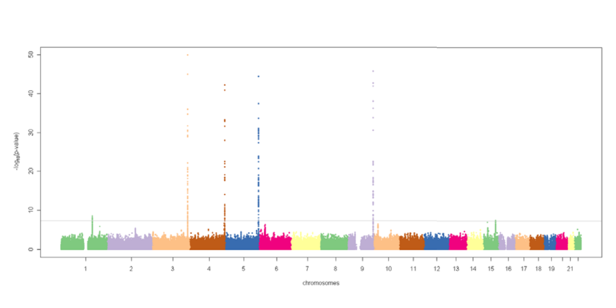

# Demo time

- tinyurl.com/AppGait2
- tinyurl.com/AppGait1

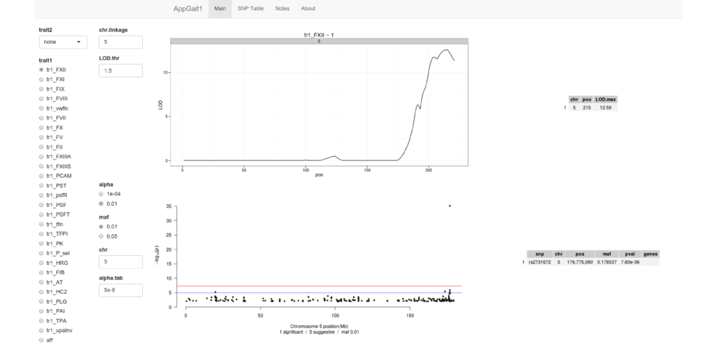

# Conclusions

# Things we’ve learned from GWAS in GAIT2

- `MatrixEQTL` requires a special tunning for related individuals
  - Passing kinship matrix doesn’t work
  - Regressing out covariates doesn’t work
  - Solution: variance-covariance matrix from the polygenic model
- Power of GWAS in GAIT2 is similar to that in GAIT1
  - <1,000 individuals leads to detection of only large-effect loci
  - GWAS is dead?

# Other QTL mappings we’ve done

```r
library(gait)
phen <- gait2.phen(id.alert = TRUE, transforms = "tr1")
kin2 <- solarKinship2(phen)
snpfiles <- gait2.snpfiles(); mibddir <- gait2.mibddir()

# Multi-variate assoc.
library(solarius)
A <- solarPolyAssoc(tr1_PSfree + tr1_PSfunc ~ 1, phen, mga.files = snpfiles, cores = 64)

# Gene-based post-gwas assoc.
library(vegas)
G <- vegas(A$snpf, genesize = 10, chr = 1, cores = 64)

# PG x Discrete var.
library(solaris)
M <- relmatLmer(tr1_PSfree ~ (0+SEX|ID) + (0+SEX|RID), phen, relmat = list(ID = kin2),  weights = w, vcControl = c)

# PG x Cont. var.
M <- relmatLmer(tr1_PSfree ~ (1+AGEsc|ID) + (1+AGEsc|RID), phen, relmat = list(ID = kin2),  weights = w, vcControl = c)

# Linkage MGxE
L <- relmatLmer(tr1_PSfree ~ (1+AGEsc|ID) + (1+AGEsc|IBDID) + (1+AGEsc|RID), phen, relmat = list(ID = kin2), mibddir = mibddir, weights = w, vcControl = c)
```

# Tested ideas that failed/worked partially

- gene-based test by VEGAS2: not powerful by itselft & more SNPs are needed
- pathway-based: the first try could not work > need experts
- multi-trait GWAS: no results for the traits in Coagulation Cascade
- metaphen v2: no one had time to go further the first graphical result
- ibd estimation: go further the Alfonso’s proposal of LD prunning & found IBDLD
- sex-specificity by SOLAR: found the bug in the GAIT1 case study of mtDNA

# Things to do

- Phen. revision
  - apply exclusion criteria (e.g. Souto’s note)
  - include more traits & add more covariates, e.g. diet, physical activity
  - impute phen. based on polygenic model
- Score-based GWAS v2 (similar to modern GWAS tools, e.g. `BOLT-LMM` by Alkes Price’s group)
  - re-define MAF (based on MAC) & imputation score (e.g. 0.9)
  - estimate the correction constant based on ~ 100 random SNPs
  - save all SNPs for gene- and pathway-based follow up
  - Add X/MT Chromosomes
- Genome-wide scans
  - GWHA to detect rare loci
  - GWL: bivariate, GxE & Parent-of-origin
- Enter to the Bayesian world
  - modern GWAS, integrative models, casual models

# Thank you

Have you already given a try to github.com/ugcd/solarius?

# Additional figures

- MAF distribution
- P-values MatrixEQTL vs. lme4
- P-values GLOGS vs. SOLAR
- P-values SOLAR vs. lme4
- Metaphen v2

# MAF distribution

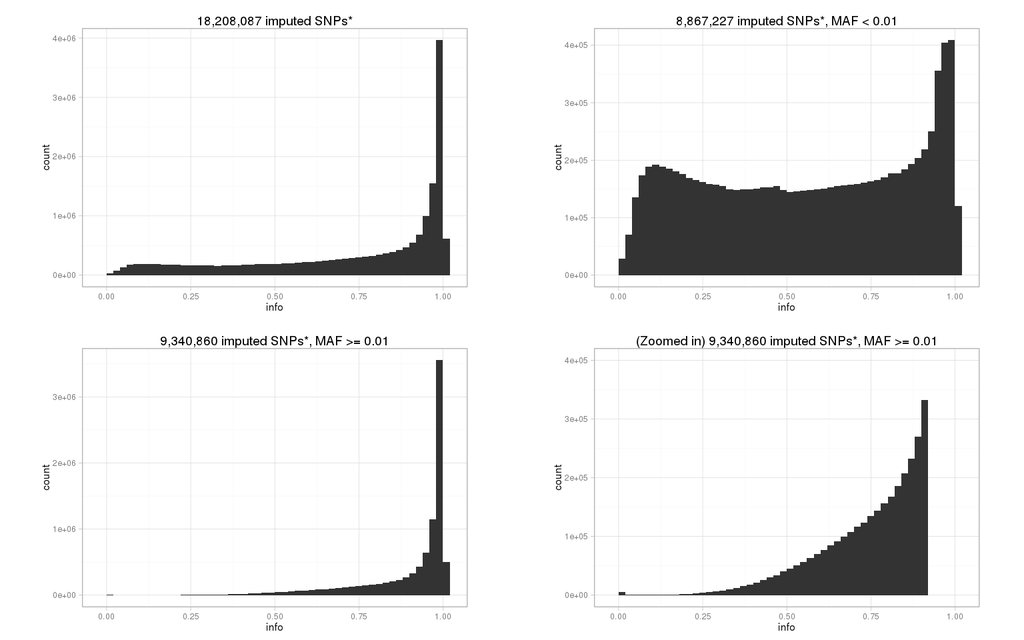

# P-values MatrixEQTL vs. lme4

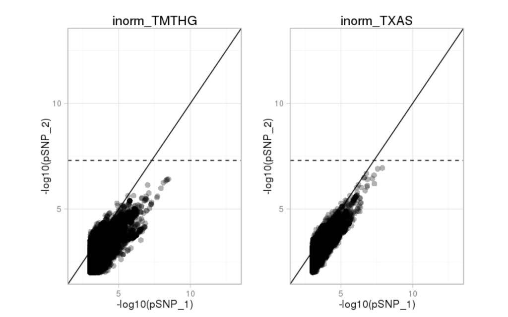

# P-values MatrixEQTL vs. lme4

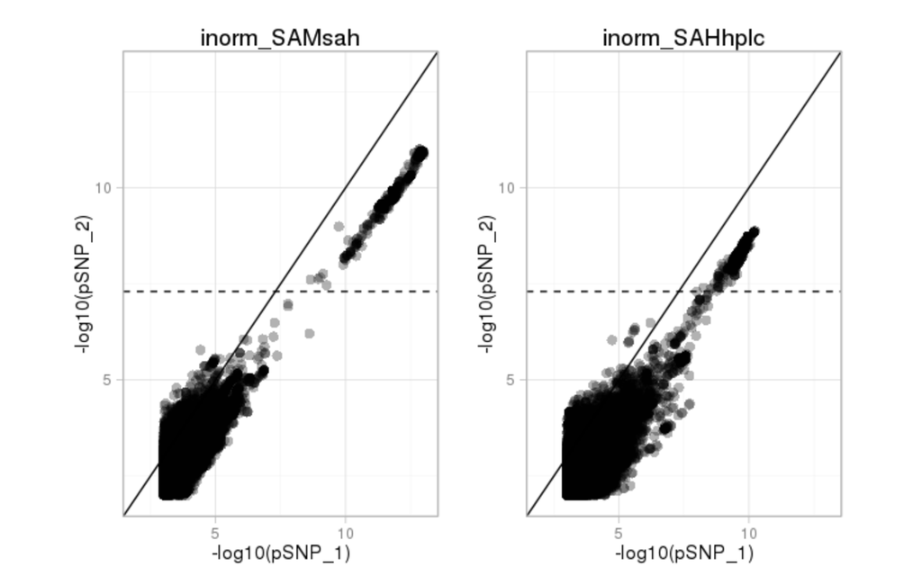

# P-values GLOGS vs. SOLAR

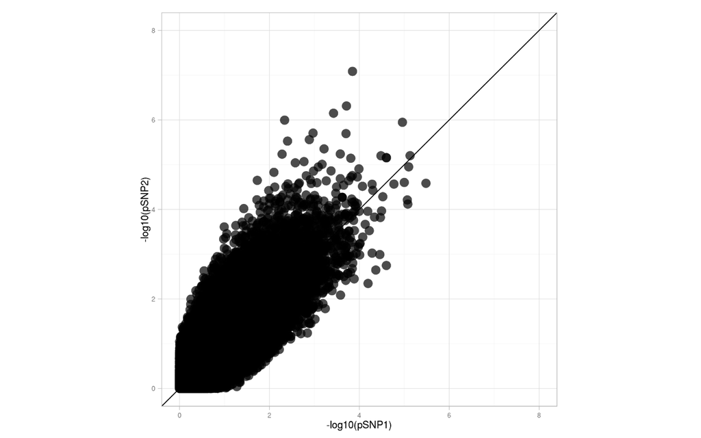

# P-values SOLAR vs. lme4

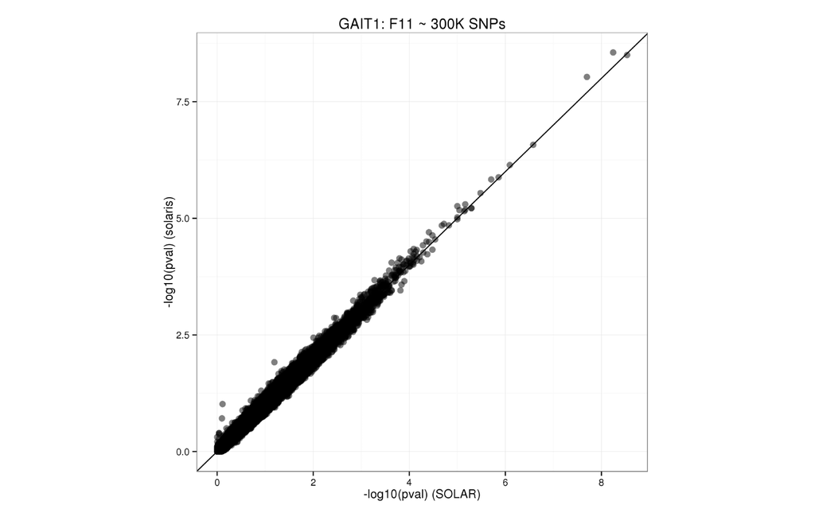

# P-values SOLAR vs. lme4

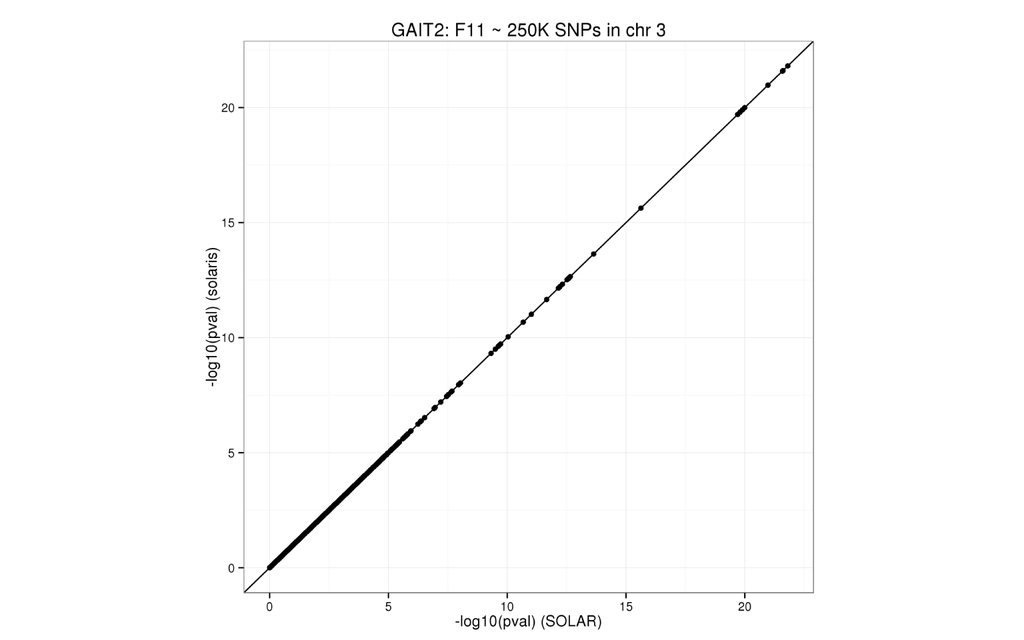

# Metaphen v2

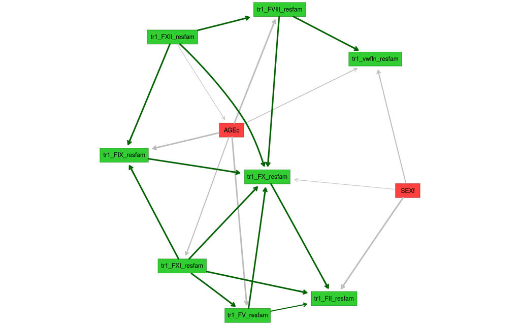